# Intro to Microbiome

Jim Arnold

August 10, 2018

Intro to microbiome analysis in R using the R markdown format so it’ll be: a) interactive b) notated so I can remember what I was thinking! Good looking out past-self, let’s do this!

I found a neat package on github and I want to work through some of their examples. Link: https://microbiome.github.io/microbiome/Tutorial.html

First, install the microbiome package. If it’s a fresh install, you need to get it from bioconductor.

```r
library(microbiome)
library(knitr)
```

Load in the data, >This data set from Lahti et al. Nat. Comm. 5:4344, 2014 comes with 130 genus-like taxonomic groups across 1006 western adults with no reported health complications. Some subjects have also short time series.

```r
data(atlas1006)
pseq <- atlas1006
print(pseq)
```

```
## phyloseq-class experiment-level object
## otu_table()   OTU Table:         [ 130 taxa and 1172 samples ]
## sample_data() Sample Data:       [ 1172 samples by 10 sample variables ]
## tax_table()   Taxonomy Table:    [ 130 taxa by 2 taxonomic ranks ]
```

This is phyloseq object. There are special calls for it, listed here: https://microbiome.github.io/microbiome/Preprocessing.html

A phyloseq object contains OTU table (taxa abundances), sample metadata, taxonomy table (mapping between OTUs and higher-level taxonomic classifications), and phylogenetic tree (relations between the taxa). Some of these are optional.

```r
summarize_phyloseq(pseq)
```

```
## Compositional = NO
## 1] Min. number of reads = 119895
## 2] Max. number of reads = 1822706
## 3] Total number of reads = 868233528
## 4] Average number of reads = 740813.590443686
## 5] Median number of reads = 700826
## 7] Sparsity = 0
## 6] Any OTU sum to 1 or less? NO
## 8] Number of singletons = 0
## 9] Percent of OTUs that are singletons 0
## 10] Number of sample variables are: 10
## age
## gender
## nationality
## DNA_extraction_method
## project
## diversity
## bmi_group
## subject
## time
## sample
```

A phyloseq object contains OTU table (taxa abundances), sample metadata, taxonomy table (mapping between OTUs and higher-level taxonomic classifications), and phylogenetic tree (relations between the taxa). Some of these are optional.

Pull the relevant data elements from the phyloseq object: metadata taxonomy abundance

```r
meta <- meta(pseq)
head(meta)
```

```
##          age gender nationality DNA_extraction_method project diversity
## Sample-1  28   male          US                  <NA>       1      5.76
## Sample-2  24 female          US                  <NA>       1      6.06
## Sample-3  52   male          US                  <NA>       1      5.50
## Sample-4  22 female          US                  <NA>       1      5.87
## Sample-5  25 female          US                  <NA>       1      5.89
## Sample-6  42   male          US                  <NA>       1      5.53
##            bmi_group subject time   sample
## Sample-1 severeobese       1    0 Sample-1
## Sample-2       obese       2    0 Sample-2
## Sample-3        lean       3    0 Sample-3
## Sample-4 underweight       4    0 Sample-4
## Sample-5        lean       5    0 Sample-5
## Sample-6        lean       6    0 Sample-6
```

```r
taxonomy <- tax_table(pseq)
head(taxonomy)
```

```
## Taxonomy Table:     [6 taxa by 2 taxonomic ranks]:
##                              Phylum
## Actinomycetaceae             "Actinobacteria"
## Aerococcus                   "Bacilli"
## Aeromonas                    "Proteobacteria"
## Akkermansia                  "Verrucomicrobia"
## Alcaligenes faecalis et rel. "Proteobacteria"
## Allistipes et rel.           "Bacteroidetes"
##                              Genus
## Actinomycetaceae             "Actinomycetaceae"
## Aerococcus                   "Aerococcus"
## Aeromonas                    "Aeromonas"
## Akkermansia                  "Akkermansia"
## Alcaligenes faecalis et rel. "Alcaligenes faecalis et rel."
## Allistipes et rel.           "Allistipes et rel."
```

```r
#absolute abundances
otu_absolute <- abundances(pseq)

#relative abundances
otu.relative <- abundances(pseq, "compositional")
```

Recommended: melt the phyloseq data for easier plotting:

```r
df <- psmelt(pseq)
head(df)
```

```
##                                      OTU     Sample Abundance age gender
## 113110 Prevotella melaninogenica et rel. Sample-448    944002  54 female
## 113015 Prevotella melaninogenica et rel. Sample-360    902034  45 female
## 112747 Prevotella melaninogenica et rel. Sample-190    862870  34 female
## 113109 Prevotella melaninogenica et rel. Sample-743    852350  52   male
## 112944 Prevotella melaninogenica et rel. Sample-366    851147  52 female
## 113639 Prevotella melaninogenica et rel. Sample-375    844482  45 female
##          nationality DNA_extraction_method project diversity   bmi_group
## 113110 CentralEurope                     o      18      5.98        lean
## 113015 CentralEurope                     o      13      5.49 severeobese
## 112747 CentralEurope                     r       7      6.06        lean
## 113109            US                  <NA>      19      5.21       obese
## 112944 CentralEurope                     o      15      5.63       obese
## 113639 CentralEurope                     o      16      5.64 severeobese
##        subject time     sample        Phylum
## 113110     448    0 Sample-448 Bacteroidetes
## 113015     360    0 Sample-360 Bacteroidetes
## 112747     190    0 Sample-190 Bacteroidetes
## 113109     743    0 Sample-743 Bacteroidetes
## 112944     366    0 Sample-366 Bacteroidetes
## 113639     375    0 Sample-375 Bacteroidetes
##                                    Genus
## 113110 Prevotella melaninogenica et rel.
## 113015 Prevotella melaninogenica et rel.
## 112747 Prevotella melaninogenica et rel.
## 113109 Prevotella melaninogenica et rel.
## 112944 Prevotella melaninogenica et rel.
## 113639 Prevotella melaninogenica et rel.
```

Data can be accessed by sample metadata and conditionals:

```r
#Abundance of a given species in each sample
head(abundances(pseq)["Akkermansia",])
```

```
## Sample-1 Sample-2 Sample-3 Sample-4 Sample-5 Sample-6
##     1319     2299    29980     3824     2133      864
```

```r
#Select a subset by metadata fields:
pseq.subset <- subset_samples(pseq, nationality == "US")

# Check sample names for African Females in this phyloseq object
s <- rownames(subset(meta(pseq), nationality == "US" & gender == "male"))
# Pick the phyloseq subset with these sample names
pseq.subset2 <- prune_samples(s, pseq)
```

Explore the estimation and analysis of various diversity indices and taxonomic composition. Diversity - https://microbiome.github.io/microbiome/Diversity.html taxonomic comp - https://microbiome.github.io/microbiome/Composition.html

```r
tab <- global(pseq, index = "all")
```

```
## Richness
```

```
## Observed (richness 0)
```

```
## Diversity
```

```
## Evenness
```

```
## Dominance
```

```
## Rarity
```

```r
head(tab)
```

```
##          richness_0 richness_20 richness_50 richness_80 observed
## Sample-1        109          99          60          25      130
## Sample-2        110          99          63          34      130
## Sample-3        109          99          59          13      130
## Sample-4        111         100          67          25      130
## Sample-5        109          98          60          27      130
## Sample-6        109          99          64          18      130
##          diversities_inverse_simpson diversities_gini_simpson
## Sample-1                   12.993537                0.9230387
## Sample-2                   16.603545                0.9397719
## Sample-3                    8.702908                0.8850959
## Sample-4                   10.711903                0.9066459
## Sample-5                   12.263397                0.9184565
## Sample-6                    9.676464                0.8966565
##          diversities_shannon diversities_fisher diversities_coverage
## Sample-1            3.189726           12.29785                    5
## Sample-2            3.396135           11.93702                    7
## Sample-3            2.866104           12.38015                    4
## Sample-4            3.058653           11.85667                    4
## Sample-5            3.076851           11.73790                    4
## Sample-6            2.945709           12.24530                    3
##          evenness_camargo evenness_pielou evenness_simpson evenness_evar
## Sample-1        0.1513312       0.6553063       0.09995028    0.06658278
## Sample-2        0.1813160       0.6977115       0.12771958    0.05993693
## Sample-3        0.1194850       0.5888204       0.06694545    0.07383716
## Sample-4        0.1398459       0.6283784       0.08239925    0.06440776
## Sample-5        0.1332354       0.6321168       0.09433382    0.06117572
## Sample-6        0.1270281       0.6051747       0.07443434    0.07016957
##          evenness_bulla dominance_dbp dominance_dmn dominance_absolute
## Sample-1      0.2902021     0.1758679     0.3377921              84316
## Sample-2      0.3293462     0.1716273     0.2820096             109940
## Sample-3      0.2381299     0.2793253     0.3985027             125664
## Sample-4      0.2896032     0.1957585     0.3813535             134094
## Sample-5      0.2662343     0.1685621     0.3332058             127719
## Sample-6      0.2649482     0.2271913     0.3799754             113490
##          dominance_relative dominance_simpson dominance_core_abundance
## Sample-1          0.1758679        0.07696134                        1
## Sample-2          0.1716273        0.06022810                        1
## Sample-3          0.2793253        0.11490412                        1
## Sample-4          0.1957585        0.09335409                        1
## Sample-5          0.1685621        0.08154347                        1
## Sample-6          0.2271913        0.10334354                        1
##          dominance_gini rarity_log_modulo_skewness rarity_low_abundance
## Sample-1      0.8486688                   2.060324           0.02460432
## Sample-2      0.8186840                   2.058091           0.01995866
## Sample-3      0.8805150                   2.056895           0.03930569
## Sample-4      0.8601541                   2.059333           0.02499865
## Sample-5      0.8667646                   2.059235           0.02370209
## Sample-6      0.8729719                   2.060673           0.03848980
##          rarity_noncore_abundance rarity_rare_abundance
## Sample-1                        0                     0
## Sample-2                        0                     0
## Sample-3                        0                     0
## Sample-4                        0                     0
## Sample-5                        0                     0
## Sample-6                        0                     0
```

Explore potential technical biases in the data. DNA extraction method reportedly has a large effect on sample grouping.

```r
# Use relative abundance data
ps <- microbiome::transform(pseq, "compositional")

# For this example, choose samples with DNA extraction information available
ps <- subset_samples(ps, !is.na(DNA_extraction_method))

# Or: you could focus on a single DNA extraction method
# ps <- subset_samples(ps, DNA_extraction_method == "r")
```

Plot PCoA by DNA extraction method. Note - this step takes a while.

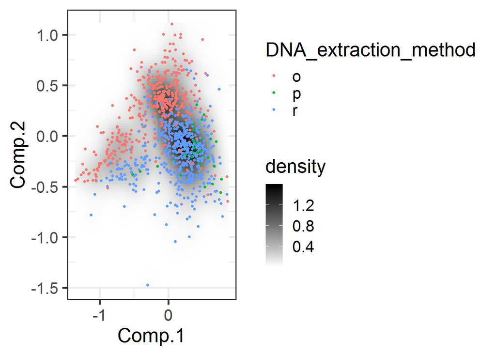

```r
# Illustrate sample similarities with PCoA (NMDS)
plot_landscape(ps, "NMDS", "bray", col = "DNA_extraction_method")
```

Core microbiota - https://microbiome.github.io/microbiome/Core.html

A full phyloseq object with just the core taxa is obtained as follows:

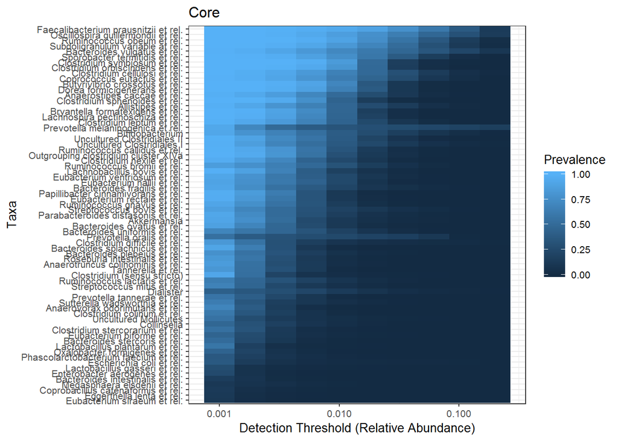

```r
# Transform to compositional abundances
pseq.rel <- microbiome::transform(pseq, "compositional")

# Pick the core (>0.1% relative abundance in 10% of the samples)
pseq.core <- core(pseq.rel, detection = 0.1/100, prevalence = 10/100)

#Visualize
prevalences <- seq(.05, 1, .05)
detections <- 10^seq(log10(1e-3), log10(.2), length = 10)

p <- plot_core(pseq.core, plot.type = "heatmap",
    prevalences = prevalences, detections = detections) +
    xlab("Detection Threshold (Relative Abundance)")
print(p)
```

Super interesting, you can play with the variables and id different taxa on the basis of frequency and/or abundance.